# Project 1

### Introduction

The purpose of this project is to implement a generalized linear model that creates a binary classification for the type of species based on skull dimensions. The raw data contains four different variables that will be used to created the model. These variables include: species type(unknown, subterraneus, multiplex), skull length, width, height. Prior to diving into implementation of the model as well as results, some exploratory data analysis is needed to inspect the data.

### Exploratory Data Analysis

The overall purpose of EDA is to give the data a bit of a sanity check for outliers as well as attempt to forecast any possible inferences we can make prior to diving into model creation.

With that being said, the first change I made to the raw data was removing blank rows. I then gave each entry a unique Vole Skull ID and complied all of the data into one sheet in excel. Then I changed the name of the column headers to something far more digestible, which can be seen below. Following that I needed to look for any potential duplicates and/or outliers to ensure the raw data was accurate. Below is a table that offers a brief overview of what the raw data looks like following the above steps.

Changes to raw data: 1. deleted blank rows. 2. Gave each skull a unique ‘vole skull index’. 3. Complied the data into one sheet in excel. 4. Removed obvious outliers by looking at a summary of each numeric variables (ie. a few entries that are roughly 10x the mean for their group) 5. changed the names of the headers to something far more digestible.

```
 ï..Vole.Skull.Index     Length         Height
 Min.   :  1.0       Min.   :1908   Min.   :700.0
 1st Qu.: 74.0       1st Qu.:2230   1st Qu.:760.0
 Median :144.0       Median :2312   Median :788.0
 Mean   :144.4       Mean   :2309   Mean   :790.9
 3rd Qu.:215.0       3rd Qu.:2388   3rd Qu.:815.0
 Max.   :288.0       Max.   :2605   Max.   :912.0
     Width
 Min.   :375
 1st Qu.:425
 Median :450
 Mean   :451
 3rd Qu.:475
 Max.   :545
```

Now lets look at some visual representations of the data. Since the overarching problems is essentially binary classification, we can take a side by side look of the data and see if any inferences can be made about the skull dimensions of either species.

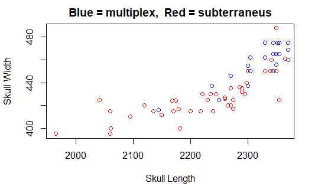

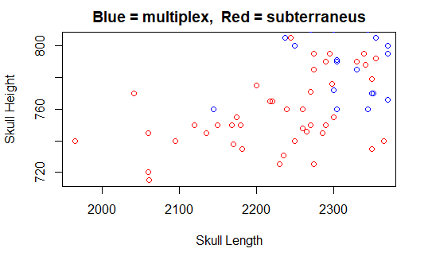

### Implementing the Generalized Linear Model

I chose to implement a logistic regression GLM because the nature of this classification problem is binary. There are only two types of species in this data set so I determined this would be the best fit. In my model, I used each of the three variables given to predict the species of the unknown monkeys.

The output of implementing my model onto the unknown species resulting in a list of probabilities. I then changed the vector of probabilities into predictions by classifying by greater than or less than .5. With binary classification, a 1 represents Subterraneus species while a score of 0 represents the Multiplex species.

```
model_1_prediction multiplex subterraneus
      multiplex           38            7
      subterraneus         5           36
```

After trying different combinations of variables I found that using each of the three given variables (or skull dimensions), led to the most accurate model. Other models I attempted led to a lower accuracy rate. The table above shows the amount of times the model inaccurately predicted the species on the training data, a total of 12 times. To speak on the usefulness of this model, I would say the model is largely accurate however it is not without error. When applied to the training data it accurately predicted the species 74/86 times. That’s a rate of 86%.

Lastly I will provide the vector of predictions in the same order that were placed in the raw data set.

```
 [1] "multiplex"    "subterraneus" "subterraneus"
 [4] "subterraneus" "multiplex"    "subterraneus"
 [7] "subterraneus" "multiplex"    "subterraneus"
[10] "subterraneus" "subterraneus" "subterraneus"
[13] "subterraneus" "subterraneus" "subterraneus"
[16] "subterraneus" "subterraneus" "subterraneus"
[19] "subterraneus" "subterraneus" "multiplex"
[22] "subterraneus" "multiplex"    "multiplex"
[25] "subterraneus" "subterraneus" "multiplex"
[28] "subterraneus" "subterraneus" "subterraneus"
[31] "subterraneus" "subterraneus" "subterraneus"
[34] "subterraneus" "subterraneus" "subterraneus"
[37] "subterraneus" "subterraneus" "subterraneus"
[40] "subterraneus" "subterraneus" "subterraneus"
[43] "subterraneus" "multiplex"    "multiplex"
[46] "multiplex"    "multiplex"    "multiplex"
[49] "multiplex"    "multiplex"    "multiplex"
[52] "multiplex"    "multiplex"    "multiplex"
[55] "subterraneus" "multiplex"    "multiplex"
[58] "multiplex"    "multiplex"    "multiplex"
[61] "multiplex"    "multiplex"    "multiplex"
[64] "subterraneus" "multiplex"    "multiplex"
[67] "subterraneus" "multiplex"    "multiplex"
[70] "subterraneus" "multiplex"    "multiplex"
[73] "multiplex"    "multiplex"    "multiplex"
[76] "multiplex"    "subterraneus" "multiplex"
[79] "multiplex"    "multiplex"    "multiplex"
[82] "multiplex"    "multiplex"    "multiplex"
[85] "multiplex"    "multiplex"
```